# Quality of life

[back to Home page |](https://github.com/huiwen-goy/C2-multidomain) [back to Analyses page |](https://huiwen-goy.github.io/C2-multidomain/C2-11Analyses.html) [Data quality |](https://huiwen-goy.github.io/C2-multidomain/C2-1Quality.html)

[Demographics |](https://huiwen-goy.github.io/C2-multidomain/C2-2Demographic.html) [Physical health |](https://huiwen-goy.github.io/C2-multidomain/C2-3Physical.html) [Hearing |](https://huiwen-goy.github.io/C2-multidomain/C2-4Hearing.html) [Cognition |](https://huiwen-goy.github.io/C2-multidomain/C2-5Cognition.html) [Mobility and balance |](https://huiwen-goy.github.io/C2-multidomain/C2-6Mobility.html) [Quality of life |](https://huiwen-goy.github.io/C2-multidomain/C2-7QoL.html) [Mental health |](https://huiwen-goy.github.io/C2-multidomain/C2-8Mental.html) [Social |](https://huiwen-goy.github.io/C2-multidomain/C2-9Social.html) [Views |](https://huiwen-goy.github.io/C2-multidomain/C2-10Views.html)

# Satisfaction With Life Scale

Responses are seven discrete options, ranging from 1 (Strongly Disagree) to 7 (Strongly Agree). The overall score is an average of responses, with higher numbers indicating better life satisfaction. No items are reverse-coded.

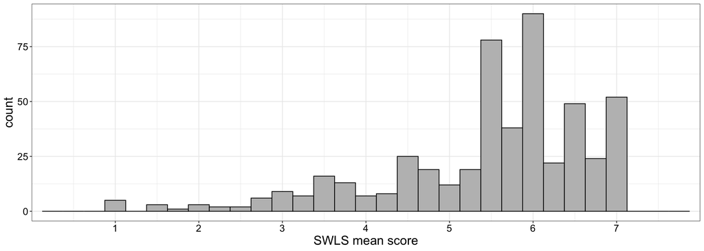

# WHOQOL-BREF

back to top

All items use 5-point scales.

Scoring procedure: Two items are analyzed individually: overall perception of quality of life, and overall perception of health. The remaining questions are clustered into four domains: Physical health, psychological health, social relationships, and environment. Three items are reverse-coded. Responses within each domain are averaged to create mean domain scores, which are then multiplied by 4 to make domain scores comparable with scores from the WHOQOL-100. Higher scores indicate a better outcome.

The WHOQOL-BREF scoring procedure allows up to 1 or 2 missing responses in a domain per participant, depending on the domain. For missing responses, the average domain score is used as a substitute. The domain score for that participant is invalid if there are too many missing responses. If the participants is missing >20% of their data overall, their overall WHOQOL-BREF score is invalid.

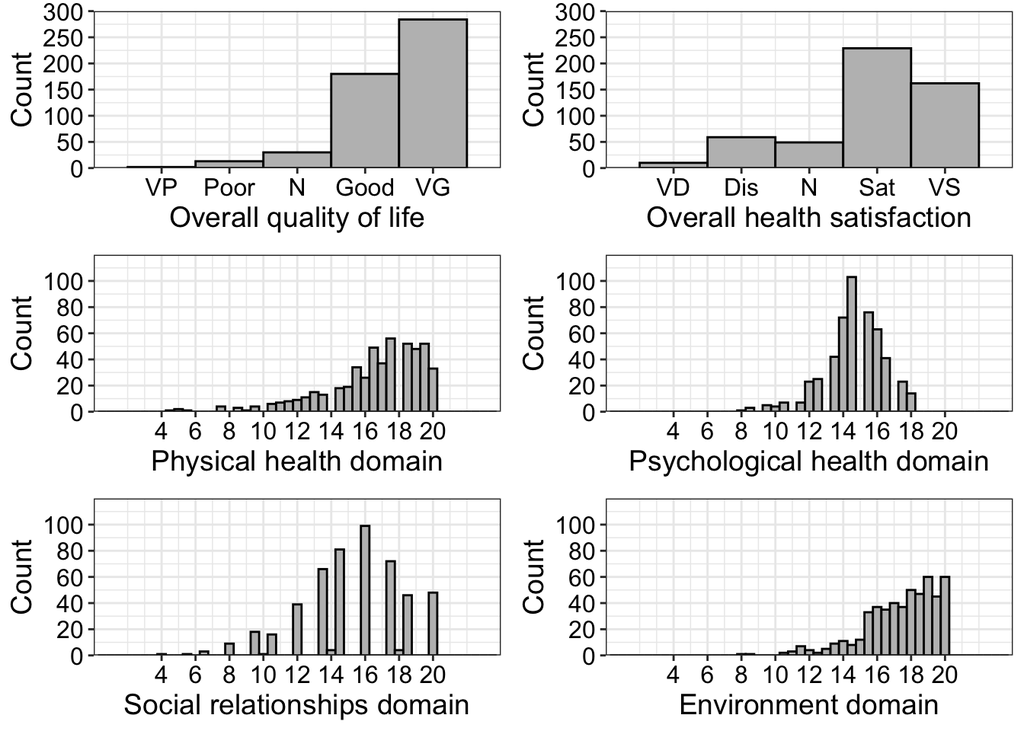

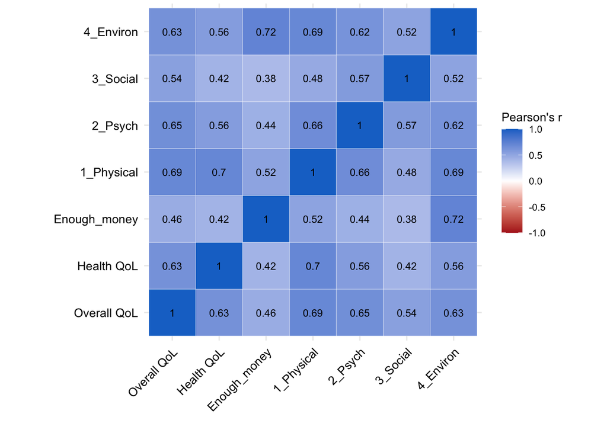

# Other variables available

back to top